# Визуализация данных о поездках такси в Нью-Йорке

Морозова Ю.А., Баркова З.А.

2017-09-29

# Описание набора данных

Набор данных для этого примера был опубликован организацией NYC Taxi and Limousine Commission (TLC) и включает записи о всех поездках двух провайдеров - Желтого и Зеленого такси за период с января по июнь 2016 года. Этот набор данных использовался для предсказания длительности поездки пассажиров и включает следующие переменные:

- X - номер каждой поездки;
- id - идентификатор каждой поездки;
- vendor_id - код провайдера услуг такси;
- pickup_datetime - дата и время посадки пассажиров;
- dropoff_datetime - дата и время высадки пассажиров;
- passenger_count - количество пассажиров;
- pickup_longitude - долгота места посадки пассажиров;
- pickup_latitude - широта места посадки пассажиров;
- dropoff_longitude - долгота места высадки пассажиров;
- dropoff_latitude - широта места высадки пассажиров;
- store_and_fwd_flag - показывает, хранилась ли запись о поездке в памяти транспортного средства до того, как была отправлена провайдеру, так как у автомобиля не было соединения с сервером - Y = хранилась; N = нет;
- trip_duration - длительность поездки в секундах;
- Nearest_PickupCity - ближайший город к месту посадки пассажиров;
- Nearest_DropoffCity - ближайший город к месту высадки пассажиров.

# Подготовительная работа

## Загрузка данных

```r
library(tidyverse)
library(lubridate)
library(geosphere)
library(maps)
library(stringr)
```

Загрузим данные из файла `NYtaxi.zip`. Чтобы распаковать архив, в котором содержится файл `NYtaxi.csv`, воспользуемся функцией `unz()`.

```r
data_url <- 'http://rawgit.com/postlogist/big_datasets/master/ny_taxi/NYtaxi.zip'

# Скачиваем данные из репозитория, если файла нет на компьютере
if (!file.exists('NYtaxi.zip')) {
  download.file(data_url,
                destfile = 'NYtaxi.zip',
                mode = 'wb')
}

# Извлекаем файл из архива и загружаем в R
taxi <- unz('NYtaxi.zip', 'NYtaxi.csv') %>%
  read_csv()
```

Набор данных содержит 1048575 наблюдений о поездках и 14 переменных, описанных выше. Выведем краткую обобщающую сводку по набору данных.

```r
summary(taxi)
```

```
##        X1               id              vendor_id
##  Min.   :      0   Length:1048575     Min.   :1.000
##  1st Qu.: 262145   Class :character   1st Qu.:1.000
##  Median : 524288   Mode  :character   Median :2.000
##  Mean   : 524287                      Mean   :1.535
##  3rd Qu.: 786430                      3rd Qu.:2.000
##  Max.   :1048574                      Max.   :2.000
##  NA's   :3                            NA's   :3
##  pickup_datetime               dropoff_datetime
##  Min.   :2016-01-01 00:00:17   Min.   :2016-01-01 00:03:31
##  1st Qu.:2016-02-17 15:57:17   1st Qu.:2016-02-17 16:14:13
##  Median :2016-04-01 16:11:10   Median :2016-04-01 16:29:40
##  Mean   :2016-04-01 09:21:55   Mean   :2016-04-01 09:37:57
##  3rd Qu.:2016-05-15 02:58:26   3rd Qu.:2016-05-15 03:14:09
##  Max.   :2016-06-30 23:59:39   Max.   :2016-07-01 23:02:03
##  NA's   :3                     NA's   :3
##  passenger_count pickup_longitude pickup_latitude dropoff_longitude
##  Min.   :0.000   Min.   :-78.55   Min.   :34.36   Min.   :-79.82
##  1st Qu.:1.000   1st Qu.:-73.99   1st Qu.:40.74   1st Qu.:-73.99
##  Median :1.000   Median :-73.98   Median :40.75   Median :-73.98
##  Mean   :1.664   Mean   :-73.97   Mean   :40.75   Mean   :-73.97
##  3rd Qu.:2.000   3rd Qu.:-73.97   3rd Qu.:40.77   3rd Qu.:-73.96
##  Max.   :9.000   Max.   :-61.34   Max.   :51.88   Max.   :-61.34
##  NA's   :3       NA's   :3        NA's   :3       NA's   :3
##  dropoff_latitude store_and_fwd_flag trip_duration     Nearest_PickupCity
##  Min.   :32.18    Length:1048575     Min.   :      1   Length:1048575
##  1st Qu.:40.74    Class :character   1st Qu.:    397   Class :character
##  Median :40.75    Mode  :character   Median :    662   Mode  :character
##  Mean   :40.75                       Mean   :    962
##  3rd Qu.:40.77                       3rd Qu.:   1075
##  Max.   :43.91                       Max.   :3526282
##  NA's   :3                           NA's   :3
##  Nearest_DropoffCity
##  Length:1048575
##  Class :character
##  Mode  :character
##
##
##
##
```

## Фильтрация пропущенных значений

```r
taxi <- filter(taxi, complete.cases(taxi))
```

## Преобразование дат и времени

В данных есть две колонки с датой и временем. Приведем их к типу `Date` с форматом “год-месяц-число часы:минуты:секунды” с помощью функции `ymd_hms()`:

```r
taxi <- mutate(taxi, pickup_datetime = ymd_hms(pickup_datetime),
               dropoff_datetime = ymd_hms(dropoff_datetime))
```

После приведения даты и времени к нужному формату, с ними легко делать вычисления. Например, вычитая из времени высадки время посадки, мы получим длительность поездки. Сравним рассчитанную длительность с данной в наборе, чтобы убедиться в том, что в данных нет ошибок:

```r
sum(!near(taxi$dropoff_datetime-taxi$pickup_datetime, taxi$trip_duration)) #считаем количество несовпадающих значений в двух векторах
```

```
## [1] 0
```

Несовпадений в расчетной и фактической длительности поездок нет.

## Обработка выбросов

В сводке можно заметить, что в столбце `trip_duration` максимальная длительность поездки 3526282 секунд - аномально высока. Посмотрим на ящичной диаграмме, есть ли еще выбросы. До этого переведем длительность поездки в минуты, чтобы было удобнее анализировать.

```r
taxi <- mutate(taxi, trip_duration = trip_duration/60)
```

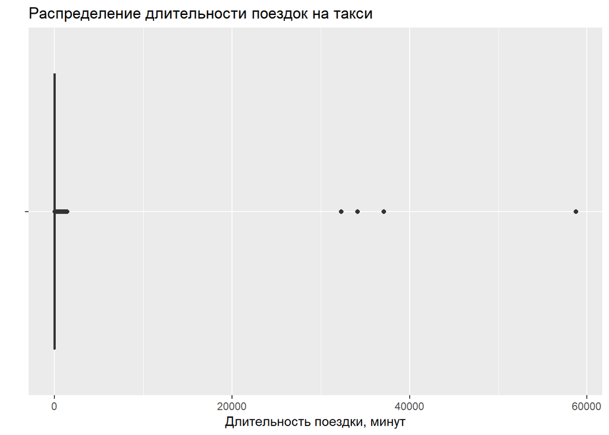

```r
ggplot(taxi) +
  geom_boxplot(aes(x='', y=trip_duration)) +
  labs(title='Распределение длительности поездок на такси',
       x = '',
       y = 'Длительность поездки, минут') +
  coord_flip()
```

Аномальные значения длительности поездки настолько велики, что на диаграмме невозможно разглядеть “усы” ящичной диаграммы. Посмотрим внимательнее на самые большие значения длительности поездок:

```r
taxi %>%
  arrange(desc(trip_duration)) %>%
  head()
```

```
## # A tibble: 6 x 14
##       X1 id        vendor_id pickup_datetime     dropoff_datetime
##    <int> <chr>         <int> <dttm>              <dttm>
## 1 978383 id0053347         1 2016-02-13 22:46:52 2016-03-25 18:18:14
## 2 924150 id1325766         1 2016-01-05 06:14:15 2016-01-31 01:01:07
## 3 680594 id0369307         1 2016-02-13 22:38:00 2016-03-08 15:57:38
## 4 355003 id1864733         1 2016-01-05 00:19:42 2016-01-27 11:08:38
## 5 295382 id0593332         2 2016-05-31 13:00:39 2016-06-01 13:00:30
## 6  73816 id0953667         2 2016-05-06 00:00:10 2016-05-07 00:00:00
## # ... with 9 more variables: passenger_count <int>,
## #   pickup_longitude <dbl>, pickup_latitude <dbl>,
## #   dropoff_longitude <dbl>, dropoff_latitude <dbl>,
## #   store_and_fwd_flag <chr>, trip_duration <dbl>,
## #   Nearest_PickupCity <chr>, Nearest_DropoffCity <chr>
```

Самые длинные поездки длились десятки тысяч минут. Хотя переменная `store_and_fwd_flag` свидетельствует о том, что данные при сборе передавались сразу на сервер, в данных должно быть была ошибка при вводе, так как расстояние между Inwood и Long Island составляет всего 12,2 мили.

Перерисуем диаграмму, ограничив в координатной системе значения по оси `y` 99-процентным квантилем.

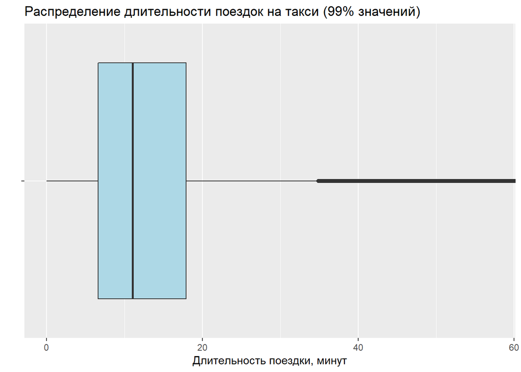

```r
ggplot(taxi) +
  geom_boxplot(aes(x='', y=trip_duration), fill="lightblue") +
  labs(title='Распределение длительности поездок на такси (99% значений)',
       x = '',
       y = 'Длительность поездки, минут') +
  coord_flip(ylim = c(0, quantile(taxi$trip_duration, probs = 0.99)))
```

```r
taxi_cleaned <- filter(taxi, trip_duration<=60)
```

# Визуализация

## Распределения длительности поездок в зависимости от провайдера услуг

Построим гистограммы распределения длительности поездок в зависимости от провайдера услуг.

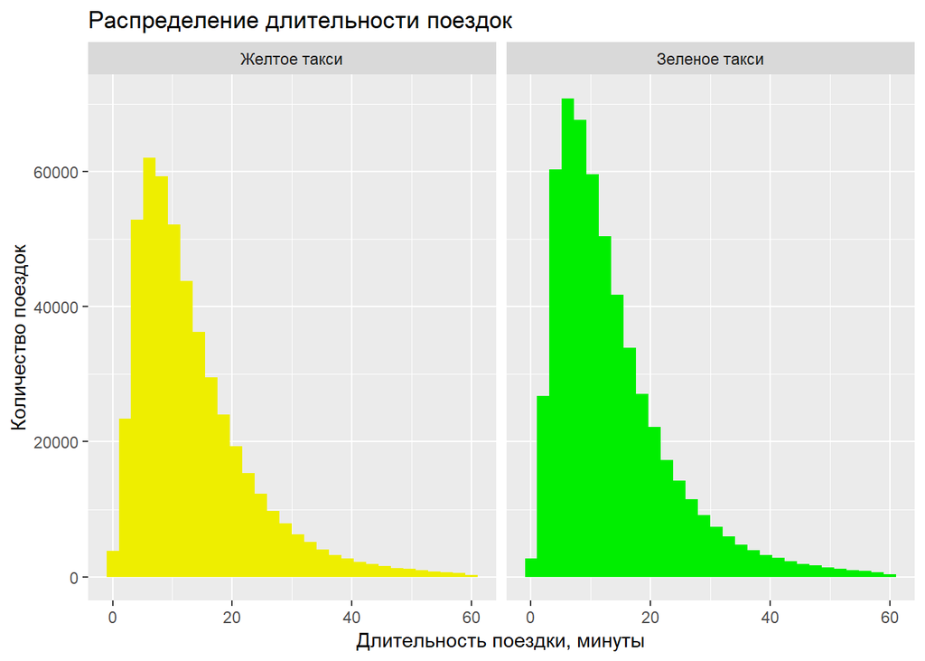

```r
ggplot(taxi_cleaned) +
  geom_histogram(aes(trip_duration, fill = factor(vendor_id)), show.legend = FALSE) + # преобразовали vector_id в factor, чтобы переменная обрабатывалась как дискретная, а не непрерывная
  facet_wrap(~ vendor_id, labeller = labeller(vendor_id = c(
    '1' = 'Желтое такси',
    '2' = 'Зеленое такси'))) +
  labs(title = 'Распределение длительности поездок',
       x = 'Длительность поездки, минуты',
       y = 'Количество поездок') +
  scale_fill_manual(values = c("yellow2","green2"))  # задание цветов заполнения гистограмм вручную
```

Можно сказать, что в целом распределения длительности поездок у обеих фирм похожи, однако у Зеленого такси, очевидно, больше количество поездок.

Построим графики плотности распределения для обоих провайдеров и сравним их функцией плотности нормального распределения.

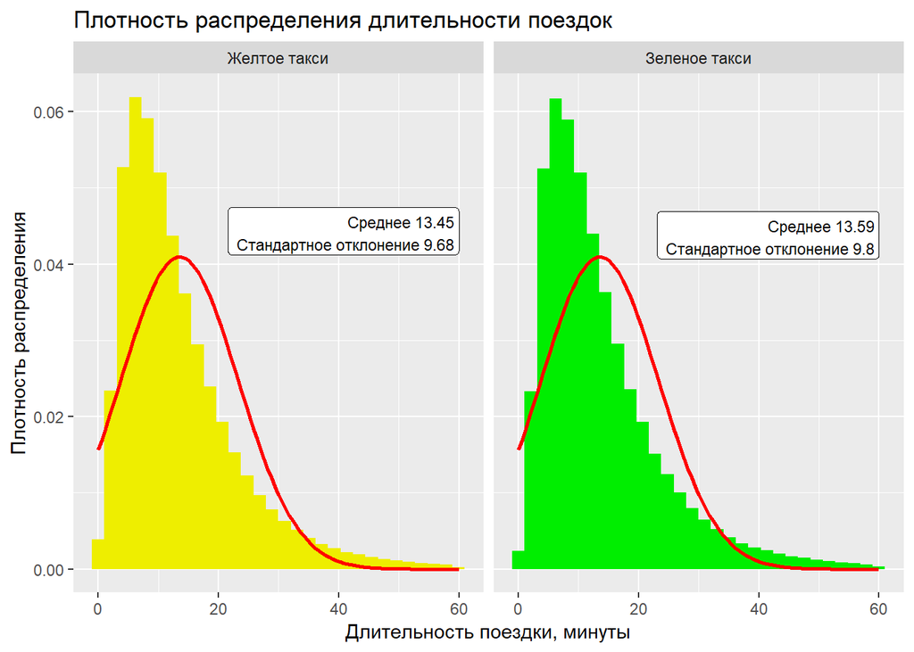

```r
lbl <- taxi_cleaned %>%
  group_by(vendor_id) %>%
  summarise(x = max(trip_duration),
            y = dnorm(x = mean(trip_duration),
                      mean = mean(trip_duration),
                      sd = sd(trip_duration)),
            label = str_c("Среднее ", round(mean(trip_duration),2),
                          "\nСтандартное отклонение ", round(sd(trip_duration),2)))

ggplot(taxi_cleaned) +
  geom_histogram(aes(x = trip_duration, y = ..density.., fill = factor(vendor_id)), show.legend = FALSE) +
  facet_wrap(~ vendor_id, labeller = labeller(vendor_id = c(
    '1' = 'Желтое такси',
    '2' = 'Зеленое такси'))) +
  labs(title = 'Плотность распределения длительности поездок',
       x = 'Длительность поездки, минуты',
       y = 'Плотность распределения') +
  scale_fill_manual(values = c("yellow2","green2"))+
  stat_function(fun = dnorm, args = list(mean(taxi_cleaned$trip_duration),
                                       sd(taxi_cleaned$trip_duration)),
              color = "red", size = 1) +
  geom_label(data = lbl, aes(x=x, y=y, label = label),
             hjust = "right", vjust = "bottom", size = 3)
```

## Динамика объемов перевозки пассажиров на такси

Посмотрим, есть ли сезонные особенности в перевозке пассажиров на такси. Для этого вычленим из даты посадки год, месяц и день недели соответственно (функции из библиотеки `lubridate`):

```r
taxi_cleaned <- mutate(taxi_cleaned,
                       pickup_year = year(pickup_datetime),
                       pickup_month = month(pickup_datetime),
                       pickup_weekdays = weekdays(pickup_datetime, abbreviate = TRUE), # использовать сокращенные названия дней недели
                       pickup_hour = hour(pickup_datetime)) %>%
  mutate(pickup_monthdate = make_date(pickup_year, pickup_month, 1)) # дата начала месяца
```

Построим столбиковую диаграмму, где по оси х - дата начала каждого месяца, а по оси у - суммарное количество количество перевезенных пассажиров. Также добавим график темпа роста количества пассажиров, значения которого будут отображатсья на дополнительной (правой) шкале y:

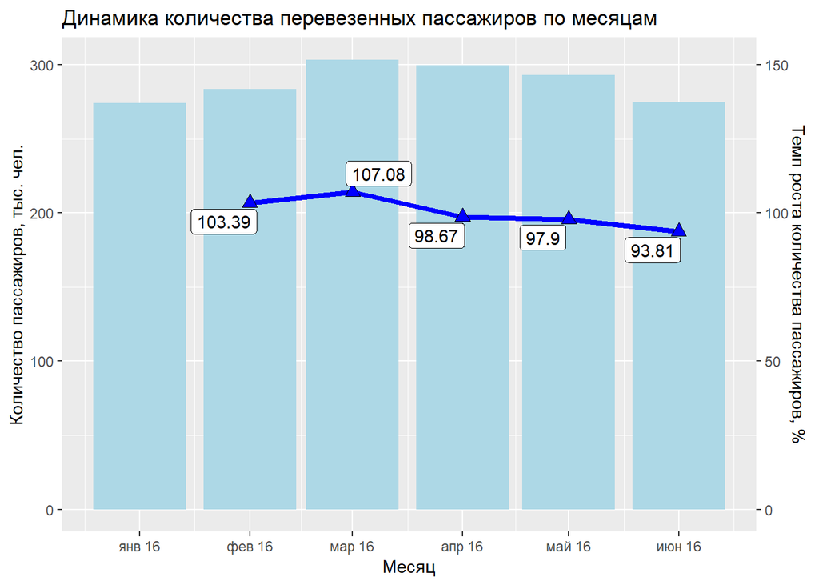

```r
taxi_cleaned %>%
  group_by(pickup_monthdate) %>% # группировка по месяцу
  summarise(pass = sum(passenger_count)) %>% # расчет суммарного количества в каждом месяце
  mutate(rate = round(pass/lag(pass)*100,2)) %>% # расчет темпа роста
  ggplot(aes(x=pickup_monthdate)) +
  geom_bar(aes(y=pass/1000), stat='identity', fill = 'lightblue') +
  labs(title = 'Динамика количества перевезенных пассажиров по месяцам',
       x = 'Месяц',
       y = 'Количество пассажиров, тыс. чел.') +
  geom_line(aes(y=rate*2), color = 'blue', size = 1.5) + # чтобы линия темпа роста была на графике повыше, умножим на 2 +
  geom_point(aes(y=rate*2), fill = 'blue', size = 3, shape=24) +
  # Добавление второй шкалы. Чтобы наименования второй шкалы соответствовали темпу роста, поделим на 2
  scale_y_continuous(sec.axis = sec_axis(~./2, name = "Темп роста количества пассажиров, %")) +
  scale_x_date(date_labels = "%b %y") +
  ggrepel::geom_label_repel(aes(y=rate*2, label = rate)) # добавление меток
```

На графике видно, что в январе-марте наблюдался подъем, а в апреле-июне падение. Однако о сезонных колебаниях по месяцам или тренде сказать ничего нельзя, т.к. данные только за 6 месяцев.

Построим график динамики количества перевезенных пассажиров по дням. Пунктиром отмечены 2,5% и 97,5% квантили. Дни, в которые наблюдался аномально высокий или низкий объем пассажиров, выделены красным.

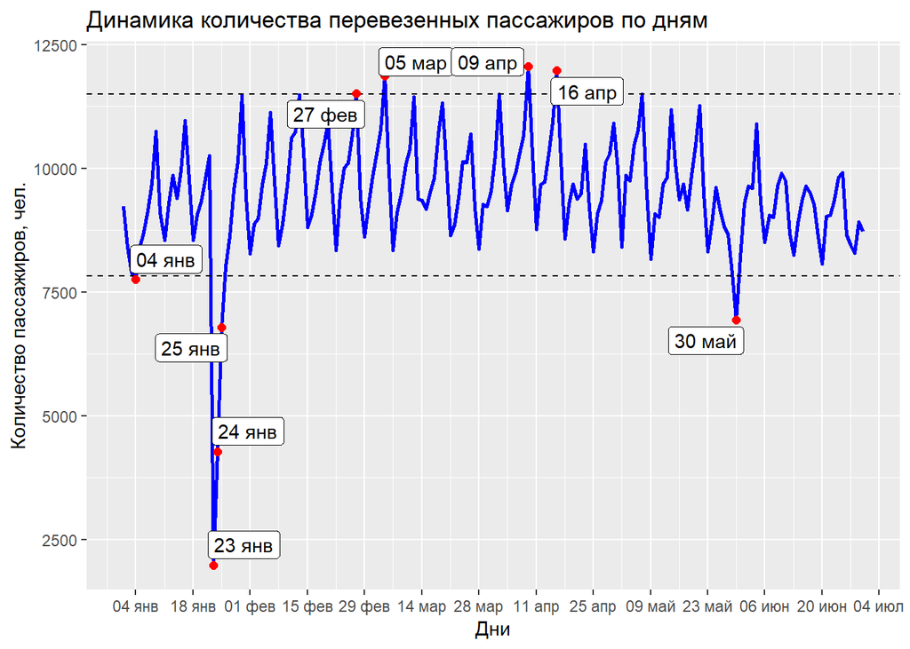

```r
taxi_by_days <- taxi_cleaned %>%
  group_by(pickup_date=date(pickup_datetime)) %>%
  summarise(pass = sum(passenger_count)) # расчет количества пассажиров по дням

pass_q975 <- quantile(taxi_by_days$pass, probs = 0.975) # расчет 97,5-процентного квантиля
pass_q025 <- quantile(taxi_by_days$pass, probs = 0.025) # расчет 2,5-процентного квантиля
extreme_pass <- filter(taxi_by_days, pass < pass_q025 | pass > pass_q975) # выборка экстремальных значений

ggplot(taxi_by_days, aes(x=pickup_date, y=pass)) +
  geom_line(color = "blue", size = 1) +
  labs(title = 'Динамика количества перевезенных пассажиров по дням',
     x = 'Дни',
     y = 'Количество пассажиров, чел.') +
  scale_x_date(date_labels = "%d %b", date_breaks = '2 weeks') +
  geom_hline(yintercept = pass_q025, linetype = 'dashed') +
  geom_hline(yintercept = pass_q975, linetype = 'dashed') +
  geom_point(data=extreme_pass, aes(x=pickup_date, y=pass), color = 'red', size=2) +
  ggrepel::geom_label_repel(data=extreme_pass, aes(label = as.character(pickup_date, format = "%d %b")))
```

Судя по периодически повторяющимся всплескам и спадам количества пассажиров, во временном ряде присутствует сезонность по дням недели.

Рассчитаем среднее количество перевозимых пассажиров такси по дням недели и отобразим на столбиковой диаграмме:

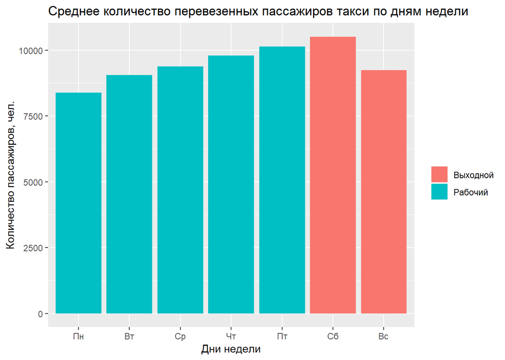

```r
taxi_cleaned %>%
  group_by(pickup_weekdays, date(pickup_datetime)) %>%
  summarise(pass = sum(passenger_count)) %>% # суммарное количество пассажиров по дням
  summarise(pass = mean(pass)) %>% # среднее количество пассажиров по дням недели
  mutate(work = ifelse(pickup_weekdays %in% c('Вс','Сб'), "Выходной", "Рабочий")) %>%
  ggplot(aes(x=factor(pickup_weekdays, levels = c('Пн','Вт','Ср','Чт','Пт','Сб','Вс')), # преобразуем в фактор, чтобы вывести правильный порядок дней недели
                      y=pass, fill = work)) +
    geom_bar(stat='identity') +
    labs(title = 'Среднее количество перевезенных пассажиров такси по дням недели',
     x = 'Дни недели',
     y = 'Количество пассажиров, чел.',
     fill = '')
```

В понедельник - наименьшее количество перевозимых пассажиров, в течение недели оно растет и достигает пика в субботу, а затем снижается.

## Зависимость времени поездки от расстояния

Проверим, наблюдается ли зависимость времени поездки от расстояния. Для этого нам нужен новый признак - расстояние. Расстояние можно посчитать с помощью функции `distHaversine` из библиотеки `geosphere`, которая рассчитывает кратчайшее расстояние между 2-мя точками на карте (по прямой, не по эллипсоиде).

```r
taxi_cleaned <- mutate(taxi_cleaned,
               distance = distHaversine(matrix(c(pickup_longitude, pickup_latitude), ncol = 2),
                     matrix(c(dropoff_longitude,dropoff_latitude), ncol = 2))/1000)
```

Выведем график зависимости длительности поездки от расстояния:

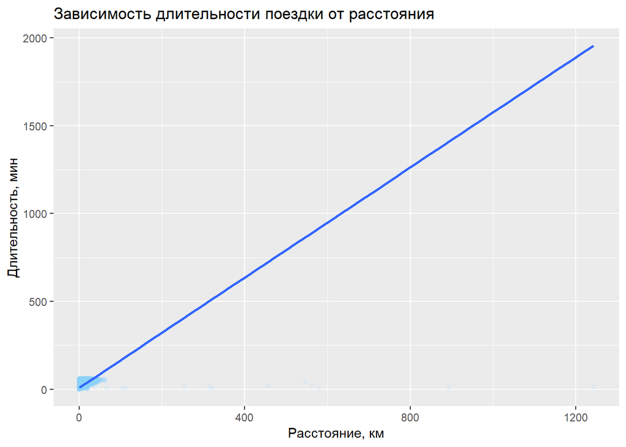

```r
ggplot(taxi_cleaned, aes(distance, trip_duration)) +
  geom_point(color = 'lightskyblue', alpha = 0.1) +
  geom_smooth(method = 'lm', se = FALSE)+
  labs(title = 'Зависимость длительности поездки от расстояния',
     x = 'Расстояние, км',
     y = 'Длительность, мин')
```

Из-за выбросов по расстоянию точки сконцентрировались в левом нижнем углу. Посмотрим поближе на нижнюю часть графика. Большинство поездок длилось менее 60 минут, и их расстояние было не более 30 км.

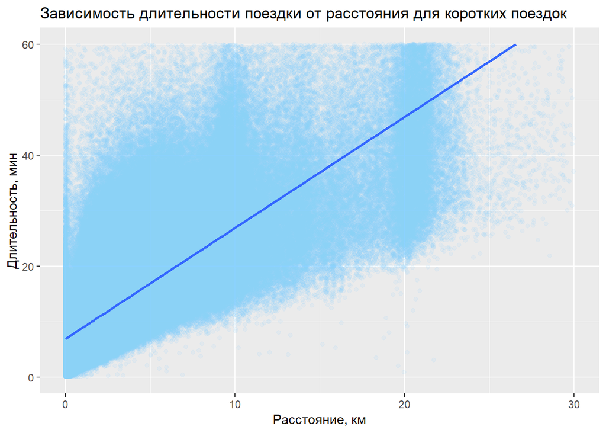

```r
ggplot(taxi_cleaned, aes(distance, trip_duration)) +
  geom_point(color = 'lightskyblue', alpha=0.1) +
  geom_smooth(method = 'lm', se = FALSE) +
  labs(title = 'Зависимость длительности поездки от расстояния для коротких поездок',
     x = 'Расстояние, км',
     y = 'Длительность, мин') +
  scale_x_continuous(limits = c(0, 30)) +
  scale_y_continuous(limits = c(0, 60))
```

На графике видно что-то похожее на линейную зависимость в его нижней части и некоторые точки с довольно продолжительным временем поездки.

## Зависимость длительности поездки от времени суток

Посмотрим, влияет ли как-то время суток на длительность поездки.

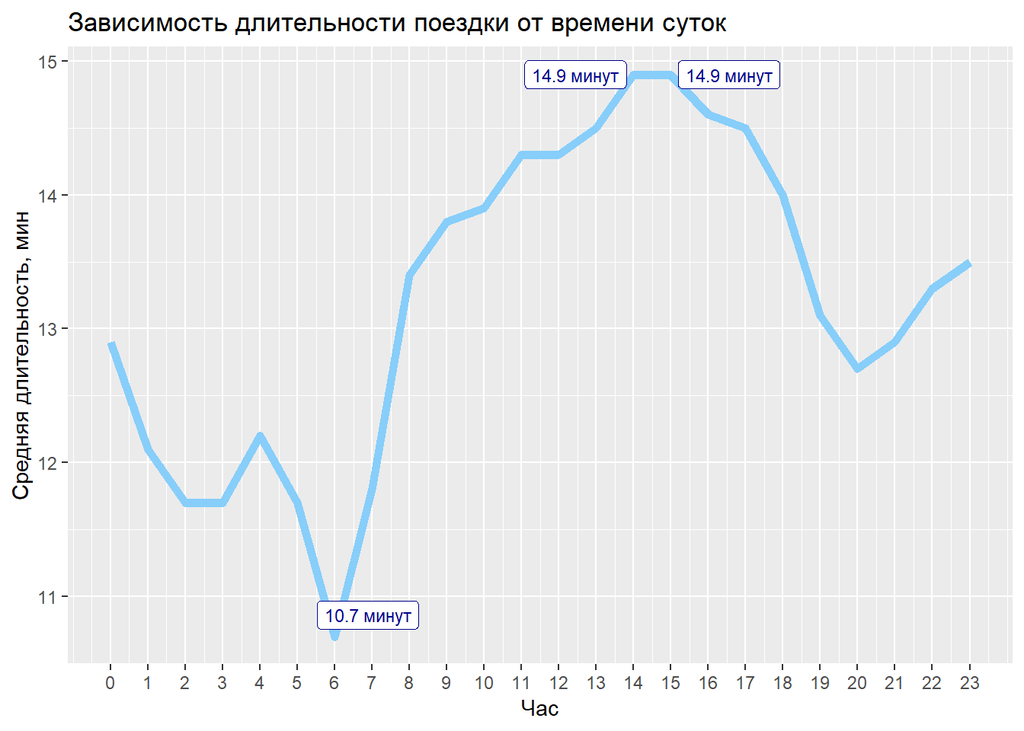

```r
taxi_by_hour <- taxi_cleaned %>%
                group_by(pickup_hour) %>%
                summarise(mean_time = round(mean(trip_duration),1))

ggplot(taxi_by_hour, aes(x=pickup_hour, y=mean_time)) +
  geom_line(color = 'lightskyblue', size=2) +
  labs(title = 'Зависимость длительности поездки от времени суток',
     x = 'Час',
     y = 'Средняя длительность, мин') +
  scale_x_continuous(breaks = seq(0,23)) + # устанавливаем деления по оси x
  ggrepel::geom_label_repel(data=filter(taxi_by_hour,
                                        mean_time == max(mean_time) |
                                          mean_time == min(mean_time)),
                            aes(label = str_c(mean_time, " минут")),
                            size=3, color = "blue4") # выводим метки для максимальной и минимальной длительности поездки
```

Предположение подтвердилось - в середине дня средняя длительность поездок была выше, чем в остальное время.

## Расположение на графике мест посадки пассажиров

Посмотрим, как выглядят поездки на карте. В качестве координат выберем координаты мест посадки пассажиров, цвет точек будет отражать количество пассажиров.

```r
states_map <- map_data("state") # получаем географические координаты штатов

str(states_map)
```

```
## 'data.frame':    15537 obs. of  6 variables:
##  $ long     : num  -87.5 -87.5 -87.5 -87.5 -87.6 ...
##  $ lat      : num  30.4 30.4 30.4 30.3 30.3 ...
##  $ group    : num  1 1 1 1 1 1 1 1 1 1 ...
##  $ order    : int  1 2 3 4 5 6 7 8 9 10 ...
##  $ region   : chr  "alabama" "alabama" "alabama" "alabama" ...
##  $ subregion: chr  NA NA NA NA ...
```

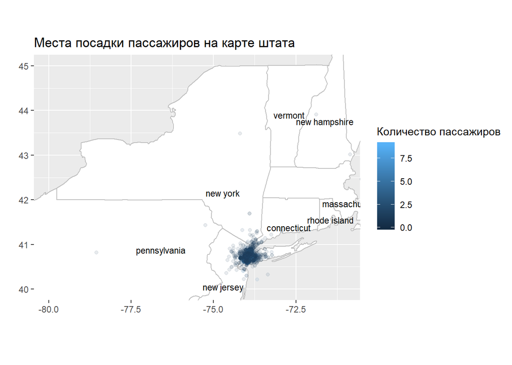

```r
states_names <- states_map %>%
  group_by(region) %>%
  summarise(long = mean(long), lat = mean(lat)) # рассчитываем координаты, где будет выведено название штата

ggplot(states_map) +
  geom_polygon(aes(long, lat, group = group), fill="white", color="grey") + #основа карты
  geom_point(data=taxi_cleaned,
             aes(pickup_longitude, pickup_latitude, color=passenger_count), alpha=0.1) + # точки посадки пассажиров на карте
coord_quickmap(ylim = c(40,45), xlim = c(-80,-71)) +
  labs(title = 'Места посадки пассажиров на карте штата',
     x = '',
     y = '',
     color = 'Количество пассажиров') +
  geom_text(data = states_names, aes(long, lat, label = region), size = 3) # выводим на карту названия штатов
```

На карту мы вывели изображение штатов, при этом чтобы лучше рассмотреть точки посадки, задали ограничения координатных осей для широты и долготы. В основном, точки собраны в городе, при этом есть несколько точек в соседних городах и несколько, вероятно, ошибочных точек в море (вряд кто-то добирался по морю на такси). Посмотрим на поездки более крупным планом. Выведем на карту (без использования фона) координаты мест посадки пассажиров.

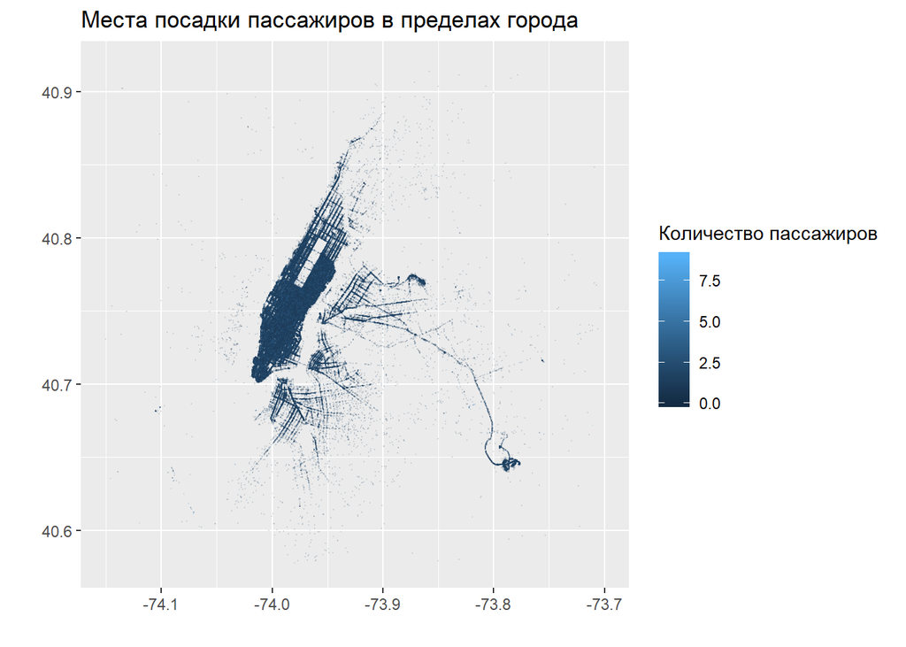

```r
ggplot(taxi_cleaned,aes(pickup_longitude, pickup_latitude)) +
  geom_point(aes(color = passenger_count), size=0.05, alpha = 0.1) +
  scale_x_continuous(limits=c(-74.15, -73.7004)) +
  scale_y_continuous(limits=c(40.5774, 40.9176)) +
  coord_quickmap() +
  labs(title = 'Места посадки пассажиров в пределах города',
     x = '',
     y = '',
     color = 'Количество пассажиров')
```

На обычном точечном графике вполне видны наиболее и наименее востребованные участки города для поездок на такси.

Красивая визуализация мест посадки пассажиров представлена [здесь](http://minimaxir.com/2015/11/nyc-ggplot2-howto/).

## Маршруты такси

Выведем на карте 100 самых длинных маршрутов поездки на такси.

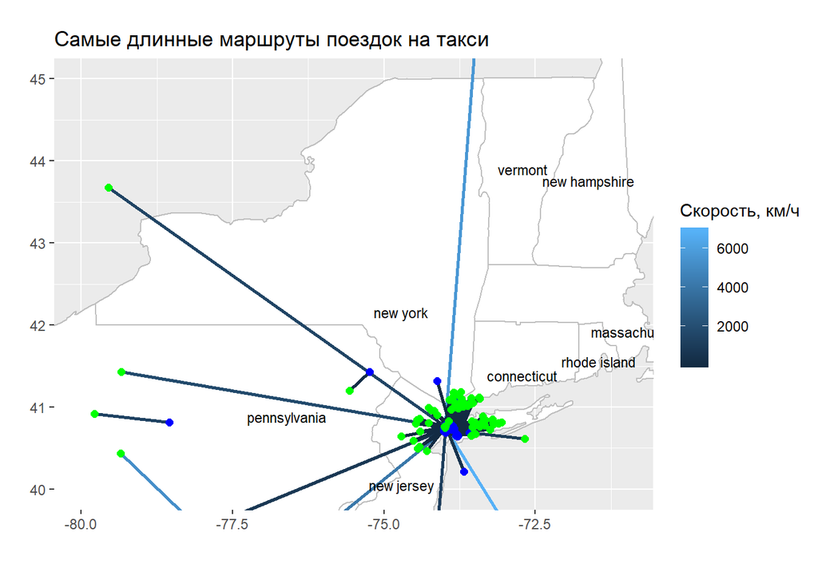

```r
taxi_long <- taxi_cleaned %>%
  mutate(speed = distance/trip_duration*60) %>% # расчет скорости в км/ч
  arrange(desc(distance)) %>% # сортировка по убыванию
  head(100)

ggplot(states_map) +
  geom_polygon(aes(long, lat, group = group), fill="white", color="grey") +
  geom_segment(data = taxi_long, aes(x = pickup_longitude, y = pickup_latitude,
                              xend = dropoff_longitude, yend = dropoff_latitude,
                              color = speed), size = 1) +
  geom_point(data = taxi_long, aes(x = pickup_longitude,
                                   y = pickup_latitude), color = "blue", size = 2)+ # места посадки
  geom_point(data = taxi_long, aes(x = dropoff_longitude,
                                   y = dropoff_latitude), color = "green", size = 2)+ # места высадки
coord_quickmap(ylim = c(40,45), xlim = c(-80,-71)) +
  labs(title = 'Самые длинные маршруты поездок на такси',
     x = '',
     y = '',
     color = 'Скорость, км/ч') +
  geom_text(data = states_names, aes(long, lat, label = region), size = 3)
```

Как можно заключить по графику, самые длинные маршруты были преодолены с космической скоростью, что, видимо, является результатом ошибочных данных. Отфильтруем данные, соответствующие неправдоподобной скорости.

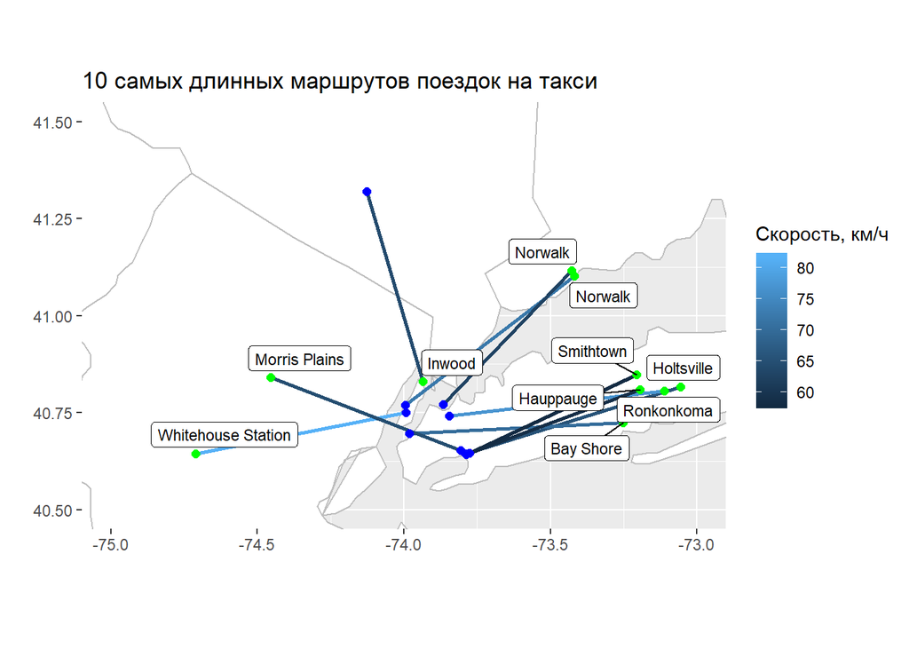

```r
taxi_long <- taxi_cleaned %>%
  mutate(speed = distance/trip_duration*60) %>% # расчет скорости в км/ч
  filter(speed < 130) %>%
  arrange(desc(distance)) %>% # сортировка по убыванию
  head(10)

ggplot(states_map) +
  geom_polygon(aes(long, lat, group = group), fill="white", color="grey") +
  geom_segment(data = taxi_long, aes(x = pickup_longitude, y = pickup_latitude,
                              xend = dropoff_longitude, yend = dropoff_latitude,
                              color = speed), size = 1) + # соединяем точки посадки и высадки прямой линией
  geom_point(data = taxi_long, aes(x = pickup_longitude,
                                   y = pickup_latitude), color = "blue", size = 2)+ # места посадки
  geom_point(data = taxi_long, aes(x = dropoff_longitude,
                                   y = dropoff_latitude), color = "green", size = 2)+ # места высадки
coord_quickmap(ylim = c(40.5,41.5), xlim = c(-75,-73)) +
  labs(title = '10 самых длинных маршрутов поездок на такси',
     x = '',
     y = '',
     color = 'Скорость, км/ч') +
  ggrepel::geom_label_repel(data = taxi_long, aes(x = dropoff_longitude,
                                  y = dropoff_latitude,
                                  label = Nearest_DropoffCity), size = 3) # метки городов высадки
```